# COVID-19 in Switzerland and Western Europe

Philippe Docourt

Last updated: 27 avril, 2020 - 17:10

# 1 Evolution in Switzerland and Western Europe

The figures do not represent the same thing in each country, depending on the extent of the screening tests carried out. Regardless of this problem, the weekly and daily trend curves allow you to get an idea of the foreseeable evolution for the next days (assuming that the screening strategy does not change over time). Respectively, it provides an indication of a possible inflection of the progression of the epidemic in the near future.

## 1.1 Switzerland

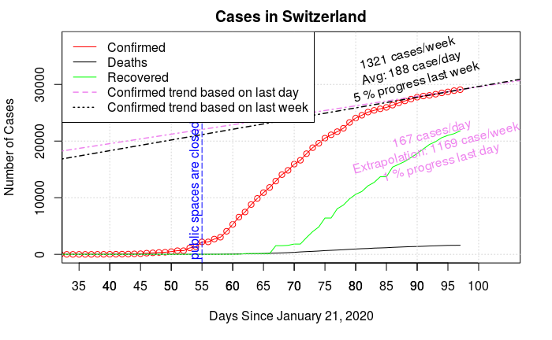

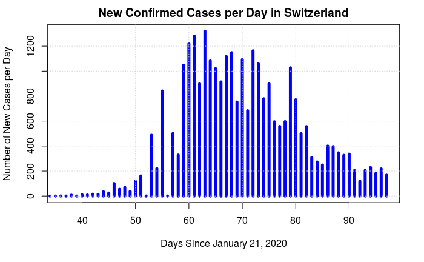

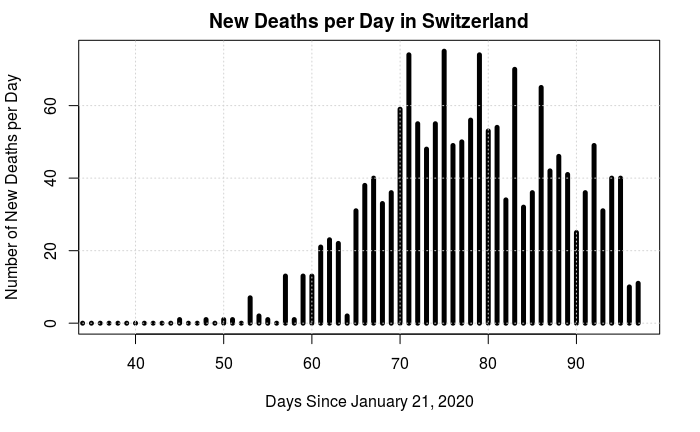

## 1.2 Italy

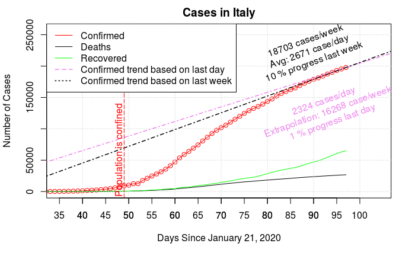

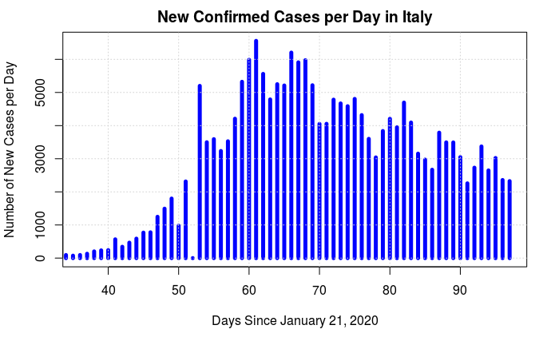

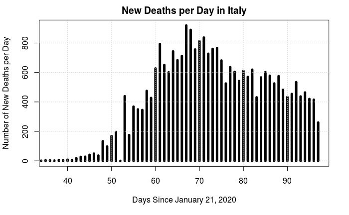

## 1.3 France

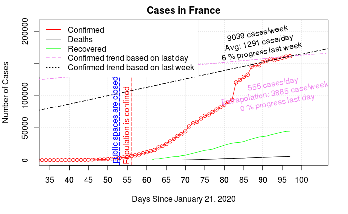

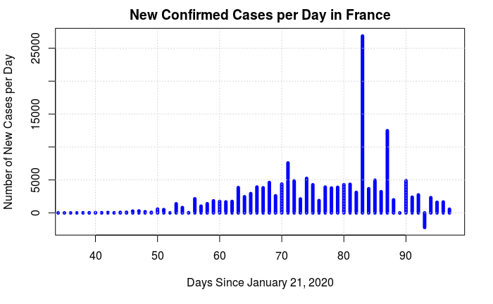

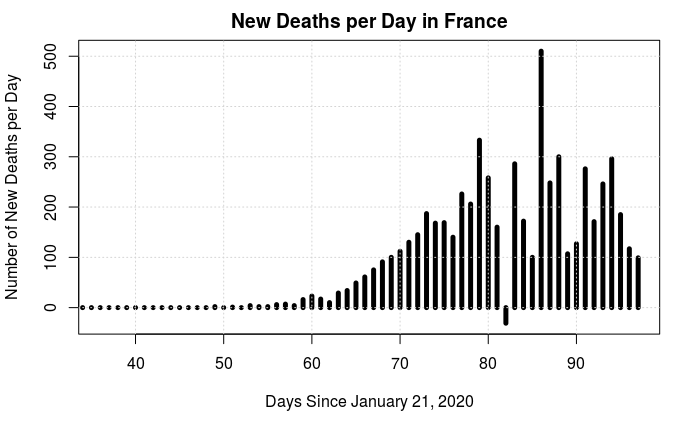

## 1.4 Germany

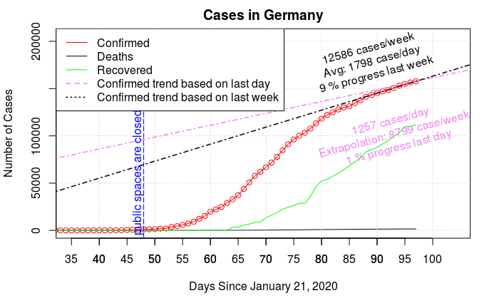

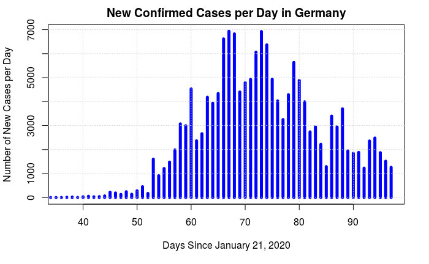

[figure not shown]

## 1.5 Austria

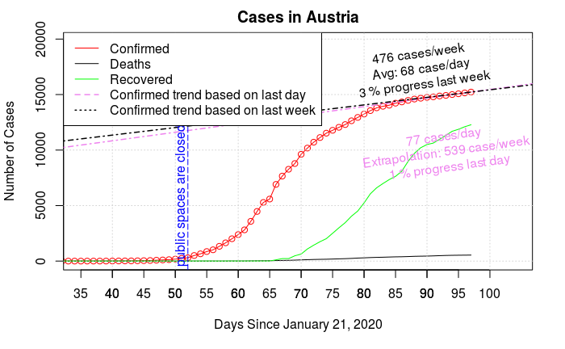

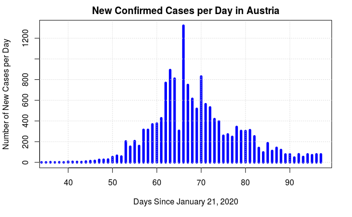

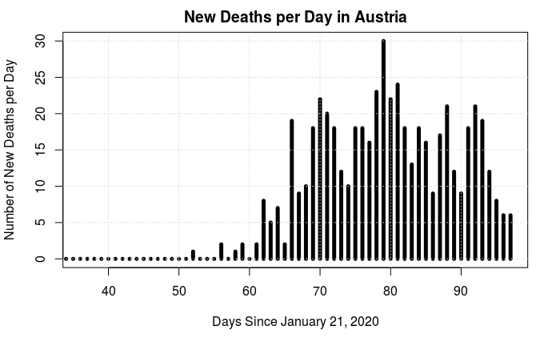

## 1.6 Spain

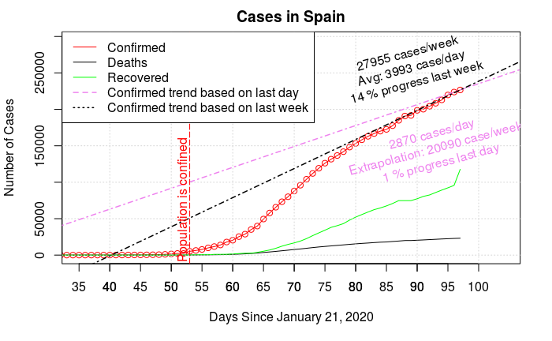

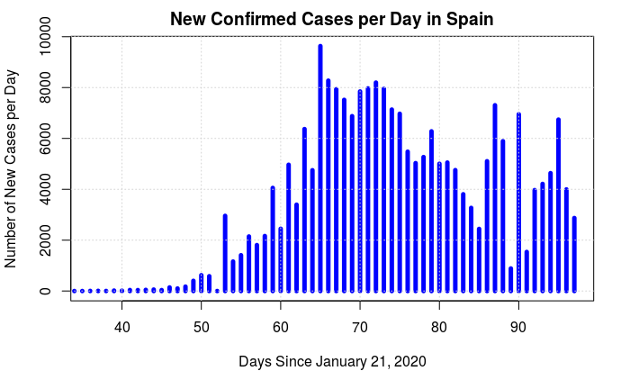

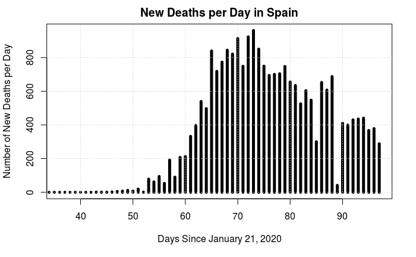

## 1.7 Great Britain

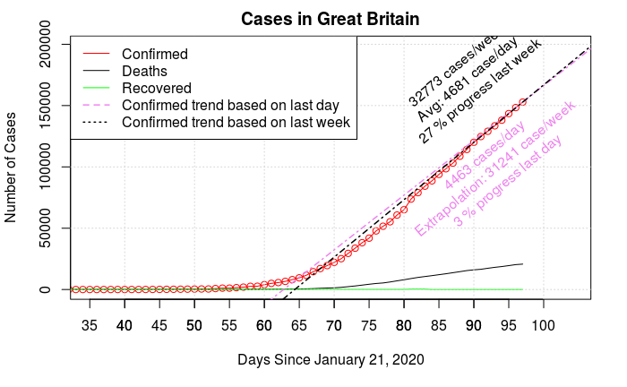

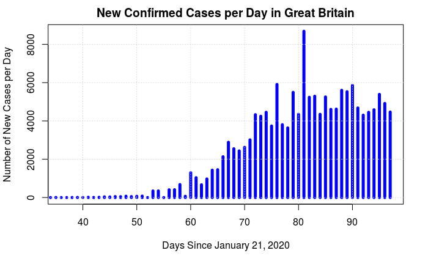

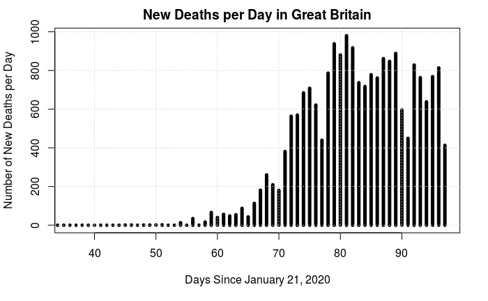

## 1.8 Denmark

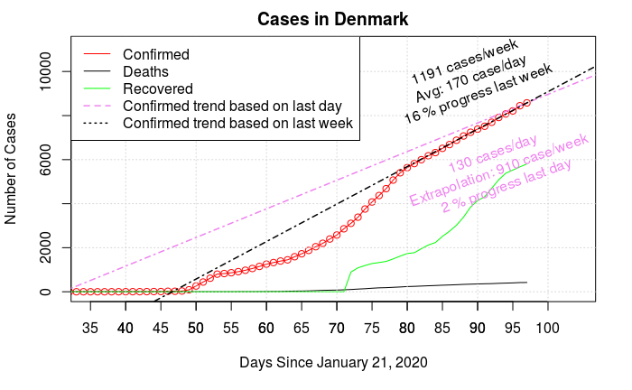

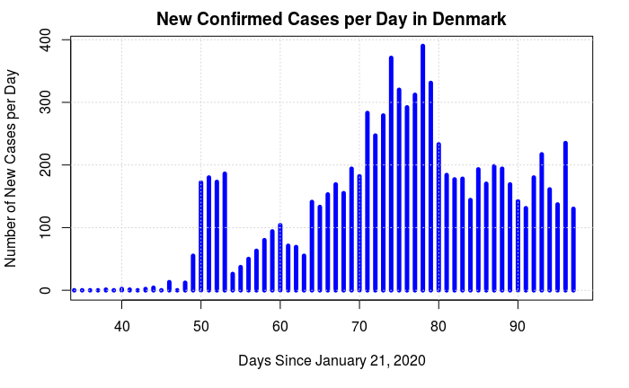

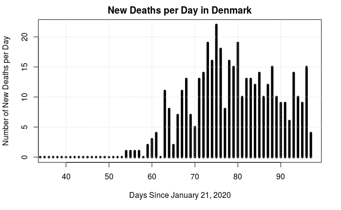

## 1.9 Norway

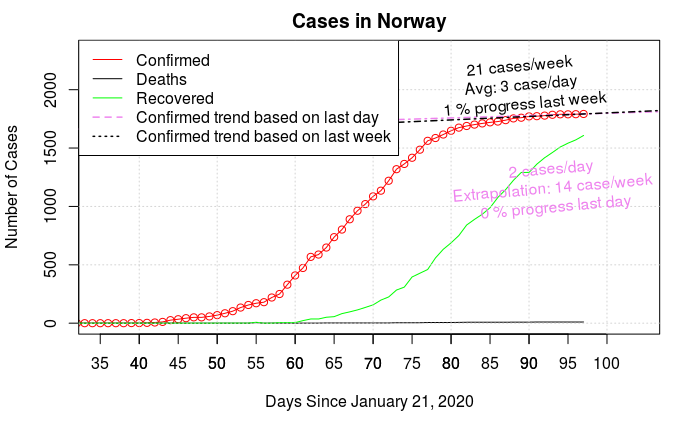

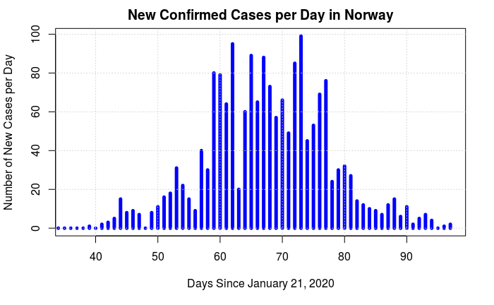

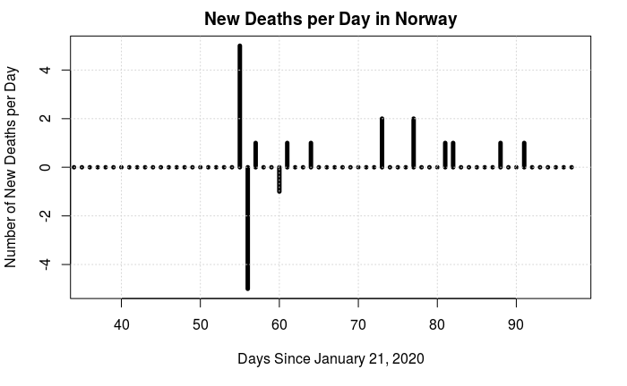

## 1.10 Sweden

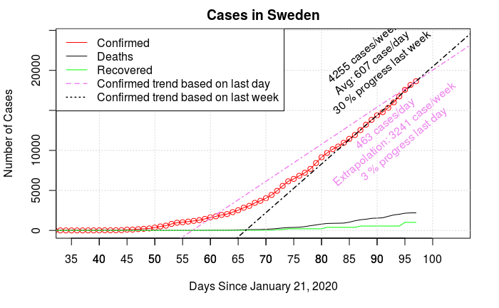

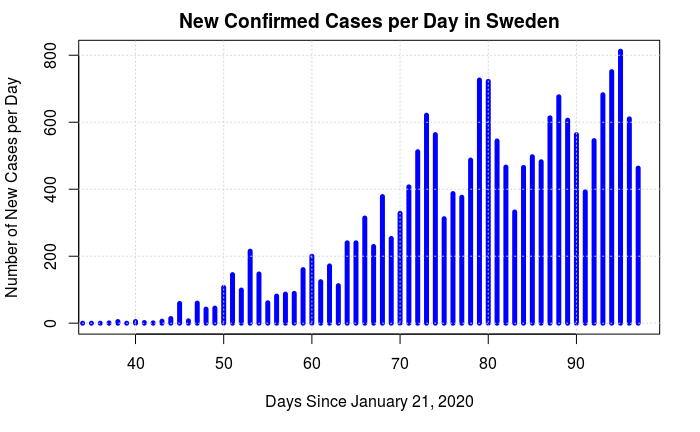

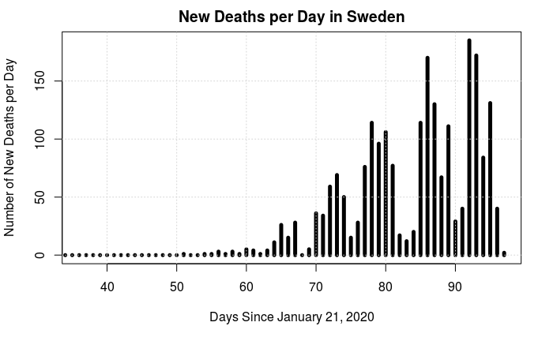